# Course Title

Week 0: Slide Templates

## Slide Title

- First point
- Second point
- Third point
- Fourth point

## Slide Title

| Column A | Column B | Column C |
| --- | --- | --- |
| 10:00 – 10:50 | 50 min | Item |
| 10:50 – 11:00 | 10 min | ☕ Item |
| 11:00 – 11:50 | 50 min | Item |
| 11:50 – 12:00 | 10 min | ☕ Item |
| 12:00 – 12:50 | 50 min | Item |

# Section Title

## Slide Title

- First point
- Second point
- Third point
- Fourth point

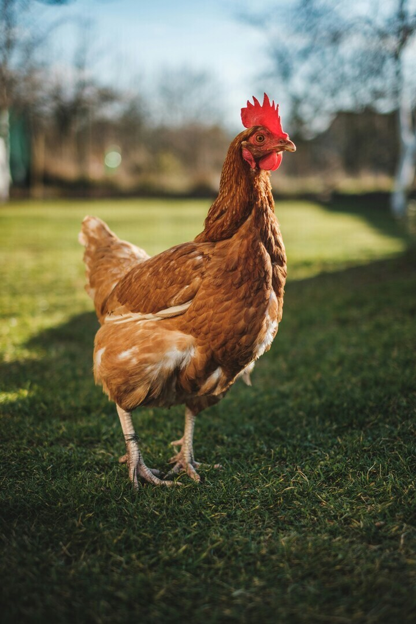

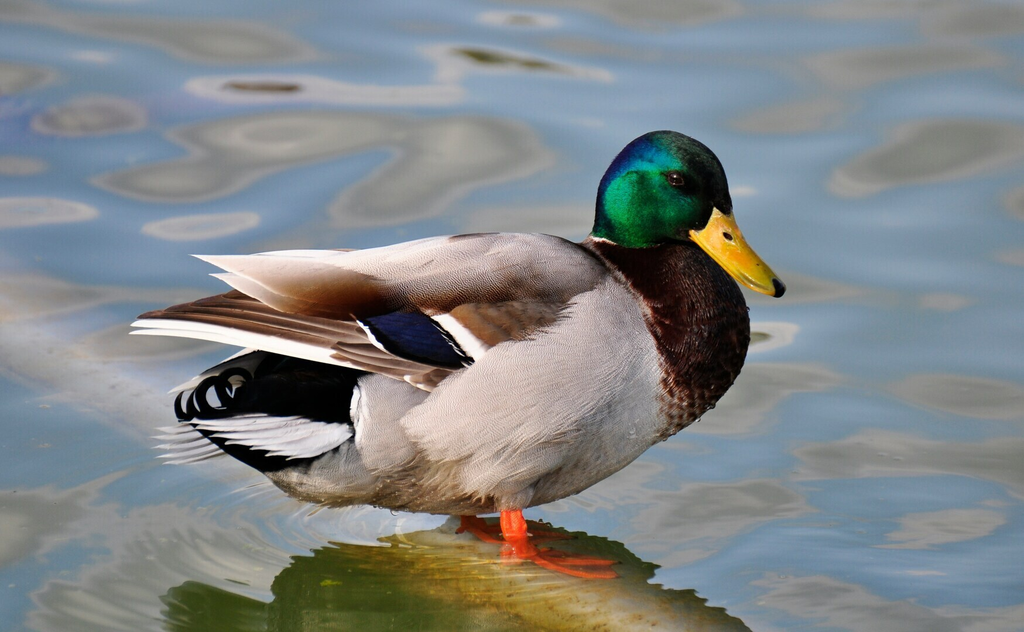

Overlay text

*“Quotation text. A second sentence of the quotation, long enough to wrap onto a second line.”*

Author Name. *Source Title*. Year.

First line of a question?  
Second line of a question?

Break ☕️

## Slide Title

Body text introducing the code:

```javascript
function setup() {
  createCanvas(400, 400);
}

function draw() {
  background('white');
  fill('red');
  circle(200, 200, 50);
}
```

**Note**

Callout text. Code blocks have a copy button in the top-right corner when viewed in a browser.

## Slide Title

**Note**

Note callout text.

**Warning**

Warning callout text.

**Important**

Important callout text.

**Tip with a title**

Tip callout text.

## Slide Title

Body text. Accent text.

The logo switches to the white version on dark slides.

**Note**

Note callout text on a dark slide.

## Slide Title

Instructions for the activity.

**~10 minutes.**

Prompts:

- First prompt
- Second prompt
- Third prompt

**Callout title**

- First tip
- Second tip
- Third tip

## Slide Title

**First heading**

- First point
- Second point
- Third point

**Second heading**

- First point
- Second point
- Third point

## Slide Title

### Subheading

*“Quotation text. A second sentence of the quotation, long enough to wrap onto a second line.”*

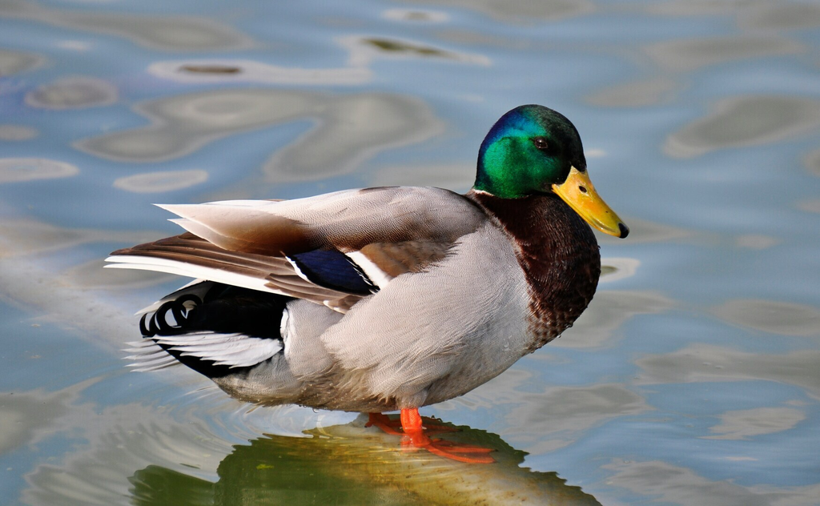

Author Name. [Source Title](https://example.com). Year.

## Schedule

**Group A:**

| Time | Name |
| --- | --- |
| 10:00 | Name 1 |
| 10:10 | Name 2 |
| 10:20 | Name 3 |
| 10:30 | Name 4 |
| 10:40 | Name 5 |
| 10:50 | Name 6 |
| 11:00 | Name 7 |
| 11:10 | Name 8 |
| 11:20 | Name 9 |
| 11:30 | Name 10 |
| 11:40 | Name 11 |
| 11:50 | Name 12 |
| 12:00 | Name 13 |
| 12:10 | Name 14 |
| 12:20 | Name 15 |
| 12:30 | Name 16 |
| 12:40 | Name 17 |
| 12:50 | Name 18 |

**Group B:**

| Time | Name |
| --- | --- |
| 10:00 | Name 19 |
| 10:10 | Name 20 |
| 10:20 | Name 21 |
| 10:30 | Name 22 |
| 10:40 | Name 23 |
| 10:50 | Name 24 |
| 11:00 | Name 25 |
| 11:10 | Name 26 |
| 11:20 | Name 27 |
| 11:30 | Name 28 |
| 11:40 | Name 29 |
| 11:50 | Name 30 |
| 12:00 | Name 31 |
| 12:10 | Name 32 |
| 12:20 | Name 33 |
| 12:30 | Name 34 |
| 12:40 | Name 35 |
| 12:50 | Name 36 |

Instruction text.

Slots are 10 minutes.

**Further instruction text.**

## Slide Title

Body text. The footer is hidden on this slide.

## Slide Title

Body text. The logo is hidden on this slide.

## Slide Title

Body text. The slide number is hidden on this slide.

## Slide Title

Body text. The footer, logo, and slide number are all hidden on this slide.

# Section Title

## Slide Title

- First task
- Second task
- Third task
- Fourth task

----> due next week

**Important**

Important callout text.

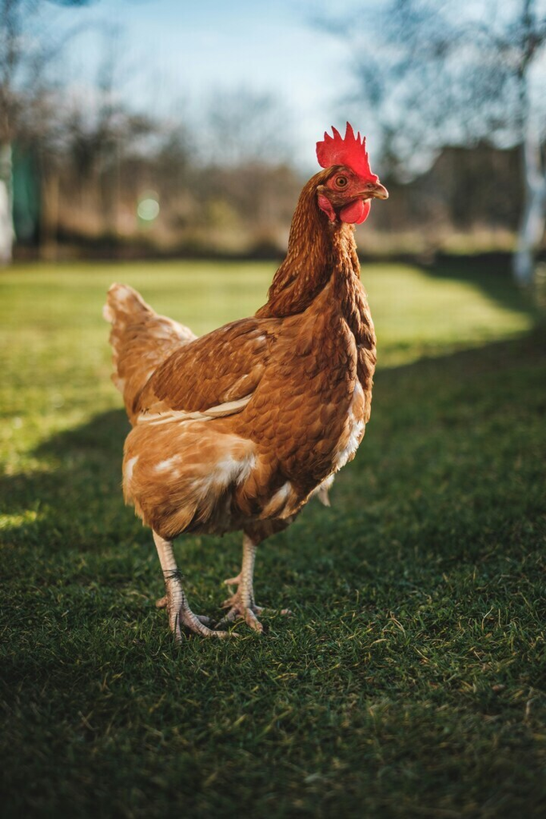